# Abalone Age Prediction using R

Diego Triana

May 4, 2020

## Abalon Data

```r
abalon_data<-read.csv("./data/abalone.data", fill = TRUE,header = FALSE)
```

The abalon data contain size is n=[4177, 9]. The columns are defined as below. The variable “Sex” appears to be a categorical input while the others are numeric. Tha variable “Sex” is likely to be related with body measurments available, this can be either male(M), female(F) or infant(I).

```r
abalon_data<-read.csv("./data/abalone.data", fill = TRUE,header = FALSE)
colnames(abalon_data) <- c("Sex","Length","Diameter","Height","Whole_weight","Shucked_weight","Viscera_weight","Shell_weight","Rings")
tail(abalon_data, n=5)
```

```
##      Sex Length Diameter Height Whole_weight Shucked_weight Viscera_weight
## 4173   F  0.565    0.450  0.165       0.8870         0.3700         0.2390
## 4174   M  0.590    0.440  0.135       0.9660         0.4390         0.2145
## 4175   M  0.600    0.475  0.205       1.1760         0.5255         0.2875
## 4176   F  0.625    0.485  0.150       1.0945         0.5310         0.2610
## 4177   M  0.710    0.555  0.195       1.9485         0.9455         0.3765
##      Shell_weight Rings
## 4173       0.2490    11
## 4174       0.2605    10
## 4175       0.3080     9
## 4176       0.2960    10
## 4177       0.4950    12
```

## Correlation

The below graph shows the correlation plot for the whole dataset. The variable “Sex” has been omitted by R. It can be seen a highly positive correlated set of inputs when “Sex” varible is not taking into account. The output variable “Rings” seems to be less correlated to its input parameters. The high values suggest that these input variables may require to be processed before learning an algorithm for age prediction. There also could be hidden characteristics nested inside the input variables, it is worth to explore such posibility.

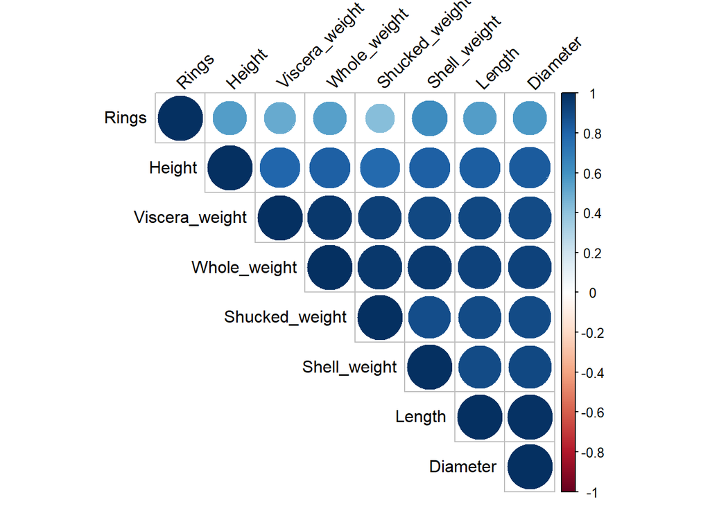

On the other hand the correlation can be split accordong to abalons gender, in this way the three groups of vectors are separated.

```r
abalon_female <-abalon_data[ which(abalon_data$Sex=='F'),]
abalon_male <- abalon_data[ which(abalon_data$Sex=='M'),]
abalon_infant <- abalon_data[ which(abalon_data$Sex=='I'),]
```

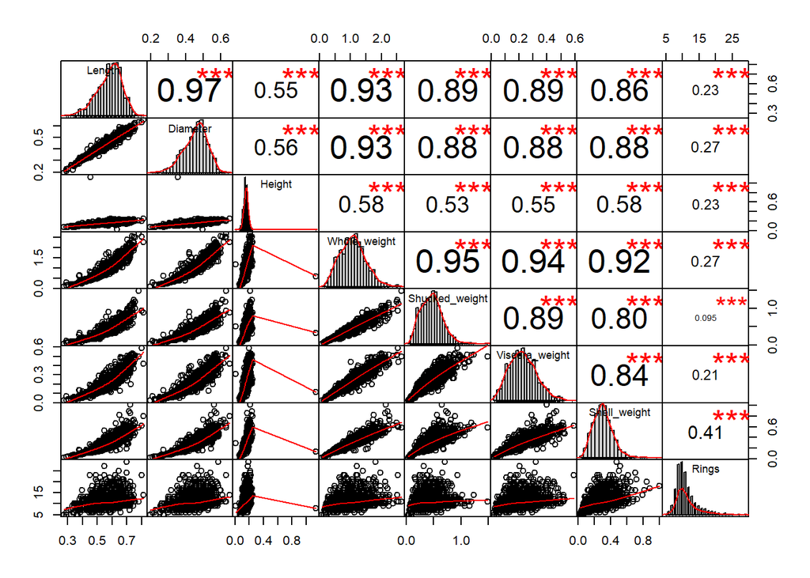

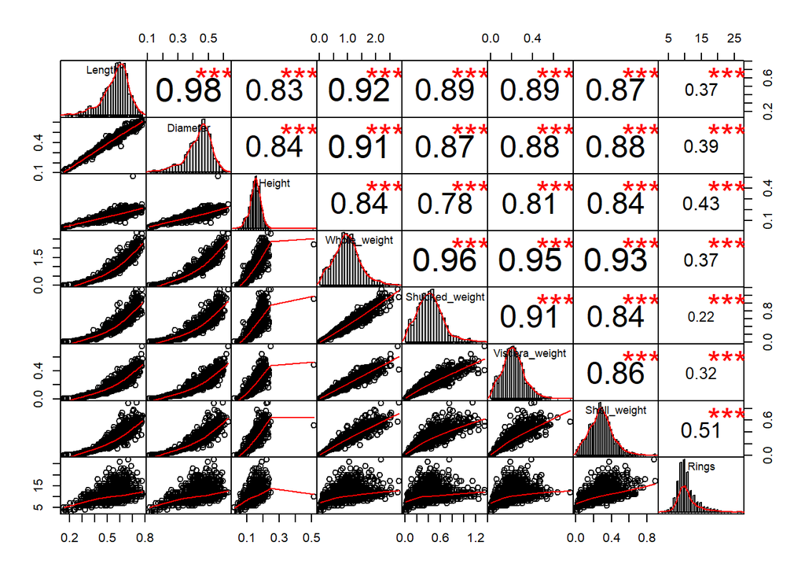

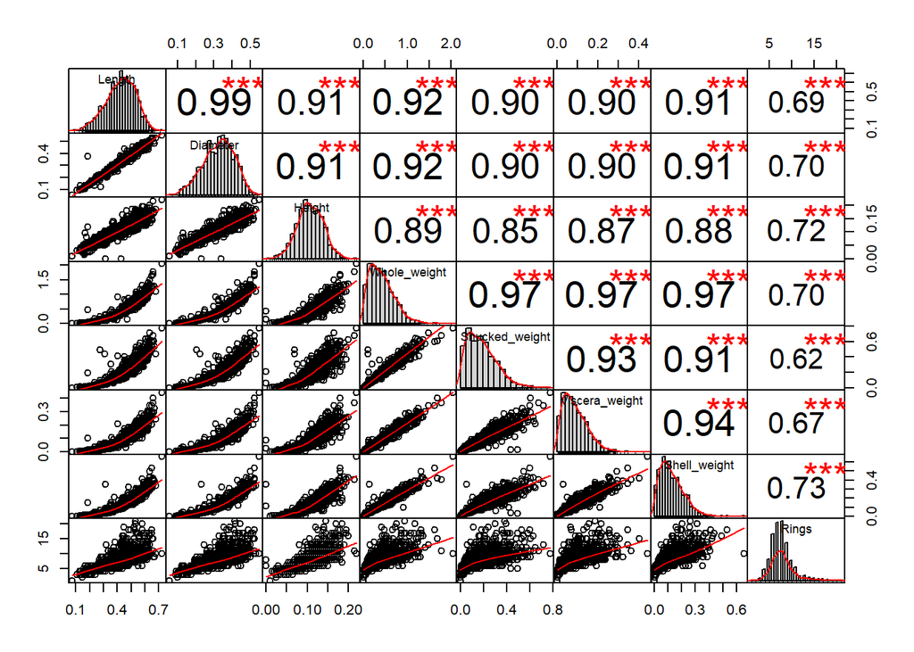

## Data processing

http://www.inference.org.uk/mackay/gpB.pdf

http://www.gatsby.ucl.ac.uk/~snelson/gpwarp.pdf